# OFB_Neighborhood_Survey_2024

Eileen Murphy

2024-08-14

#### Overall Food Security

One of the most useful data points in analyzing the Neighborhood Survey is the derived data from the calculation of the Food Security Score. This score uses a methodology established by USDA’s Economic Research Service since 1995.

The Food Security Score was based on the calculation provided by Ottawa Food Bank that documented - a six item module: (https://www.ers.usda.gov/media/8282/short2012.pdf) - Giving a score between levels 1-6, and from that score 4 levels were derived from the ranges of the scores. The 4 levels correspond to the results of the calculated scores:

- Score 1 : High Food Security (Dark Blue)
- Score 2 : Low Food Security (Lighter Blue)
- Score 3-4 : Marginal Food Security (Orange)
- Score 5-6 : Very Low Food Security

The overall composition of the Food Security for the 2024 Survey show 61.3%, that is - more than half of those surveyed are suffering from very lowest food security category being measured.

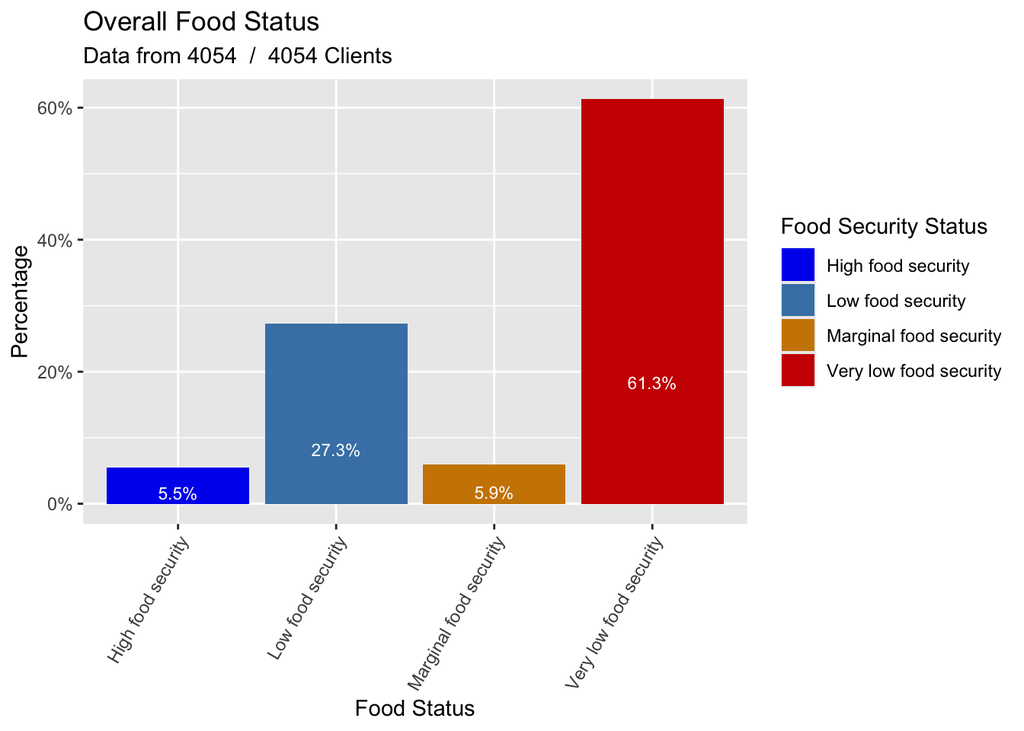

This graph produced in 2018 was provided to us by the Ottawa Food Bank to represent the intake of longitudinal studies in 2018 using both Household Food Security Survey Module (HFSSM) and the Short-Form Health Survey Version 2 (SF-12). The intake surveys were represented in 4 different waves over the 18 months. Below, is the graph that was produced to represent Food Security measures based on these surveys:

#### Past Longitudinal Studies on Food Security, 2018

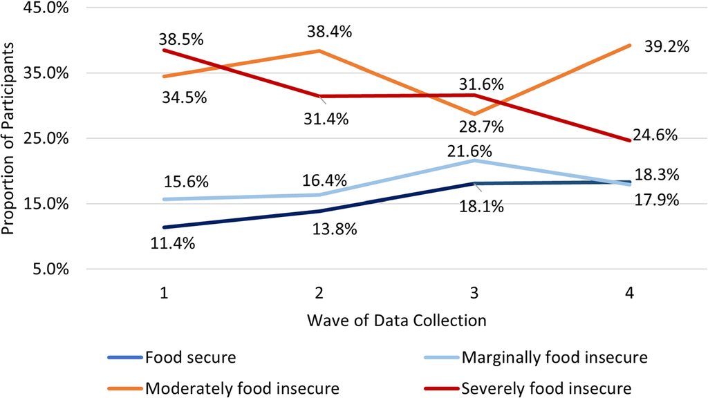

Source: (https://bmcpublichealth.biomedcentral.com/articles/10.1186/s12889-021-10841-6)

#### Updated Graph to show the addition of the 2024 data

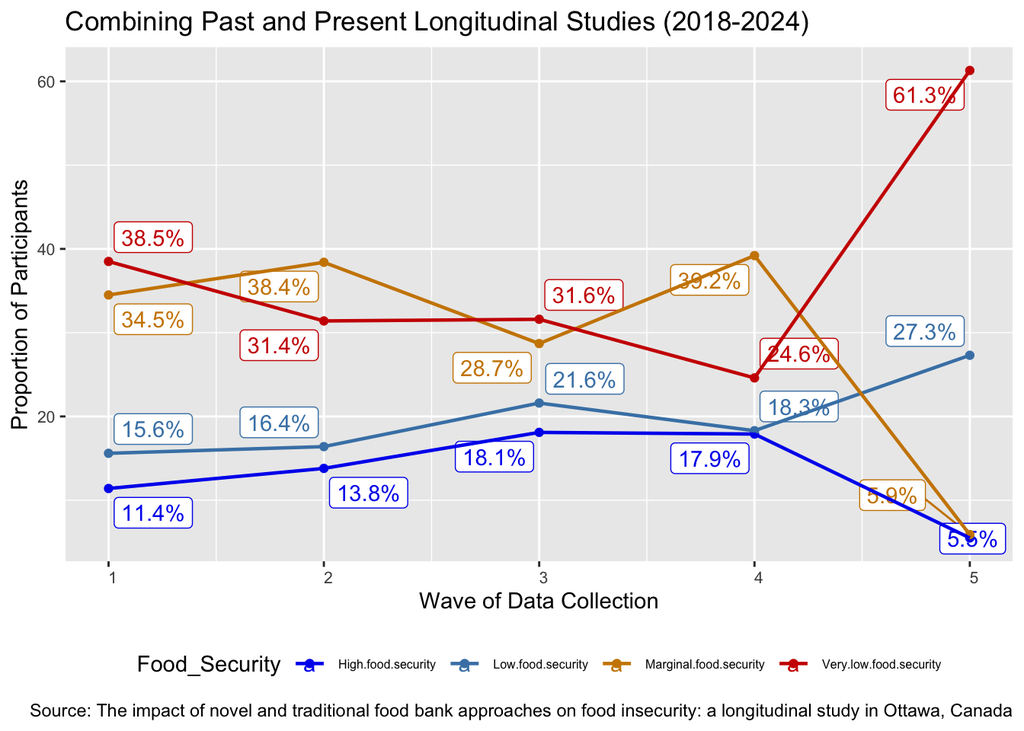

By adding a 5th wave to the above graph, we are able to compare the changes of Food Security by replicating the graph and using the same criteria to measure Food Security. The addition of the data from the 2924 survey is represented in “Wave 5”

The stresses of food insecurity can be seen visually by the downward pressure on the highest food security giving way to a rising lower (Low) food insecurity and in the same way the decrease in the marginal level of food security is appears to inversely increase the highest food insecurity.

#### Food Security vs. How Long it Takes to Get to Food Bank

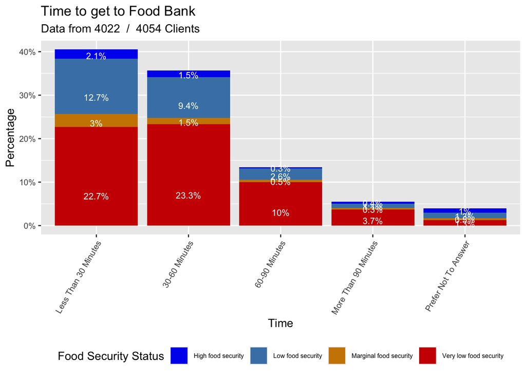

The longer it takes to get to the food bank, the less likely they are experiencing “High” food security. Instead we see less of “Low” food security and more “Very low” food security proportionally when the food bank is 60 minutes or more away.

#### Food Security vs Health Barriers

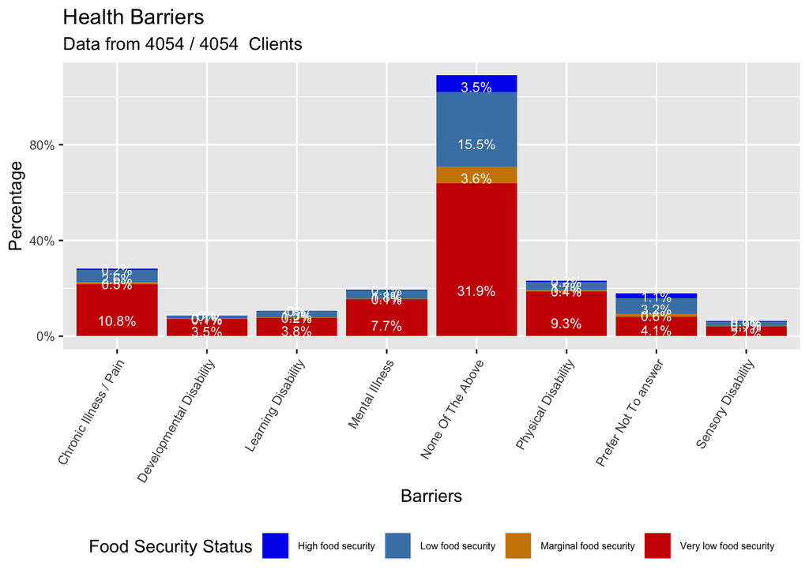

Comparing the “None Of The Above” and the “Prefer Not To Answer” with the other health barriers, we can see that the other categories have razor thin or no “Marginal” and/or “High” food security.

#### Food Security vs Housing

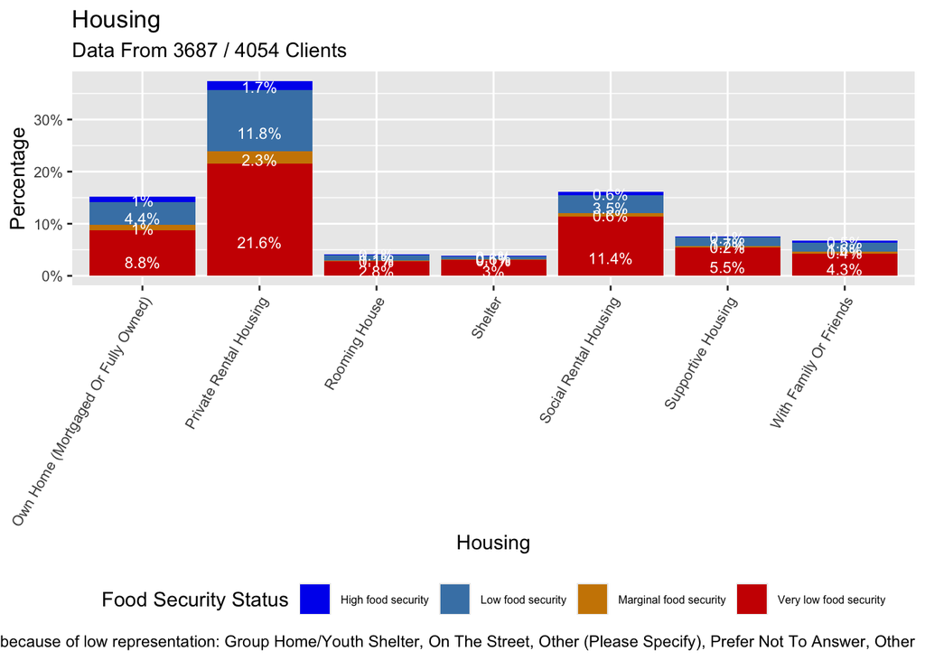

#### Isolating the categories with the least stratification:

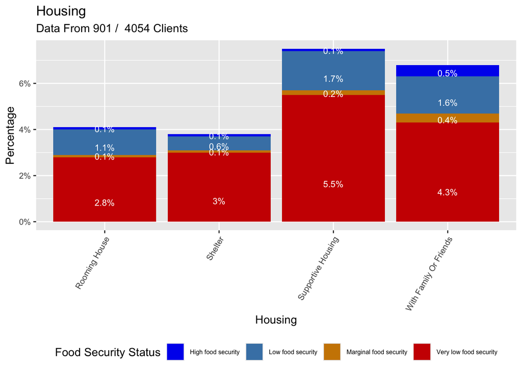

By studying and doing further analysis of the stratification layers against the overall profile in the first plot - we can begin to understand the existing situations, causes, and life-styles that affect people and their well-being.